# R Notebook

## Problem

### Business Tasks

Cyclistic is a fictional bike-share company inside Chicago. This company tasked us with the analysis of this question:  
How do annual members and casual riders **use** Cyclistic bikes differently?  
The *“casual” riders* are the clients that use single-ride and full day pass. Those offer are about **short term engagement.**  
The *“member” riders* are the clients that buy annual membership. This offer is about **long term engagement**.  
In order to convert “casual” clients into “member” clients, we could try to develop **new “transition” offer** that is about *mid term engagement*. This offer would be developed to be **attractive to “casual” clients** while being **unattractive to “member”** clients since we don’t want to convert members into casuals. In order to find opportunities for said new transition offers, we will analyse the riders behaviors.  
Let’s break this business task into sub tasks:

- Identify and categorize how users use Cyclistic services
- See how those usage relate to casual riders and annual members
- Identify usage differences and similarities between casual riders and annual members

### Audience (stakeholders in **bold**):

- **Director of marketing**
- Part of analytics team
- **Cyclistic executives**

### Data sources:

- [Cyclistic’s first-party data](https://divvy-tripdata.s3.amazonaws.com/index.html) from the last 12 months: from march 22 to February 23. Cyclistic is a fictional company so the data is provided by Motivate International Inc. The data contain one row per user’s trip. The variables are about:
  - trip’s starting hour and location
  - trip’s ending hour and location
  - customer’s membership
  - bike type

  The files used are:
  - 2022MM-divvy-tripdata/2022MM-divvy-tripdata.csv with MM the month (03 to 12)
  - 202209-divvy-tripdata/202209-divvy-publictripdata.csv
  - 2022MM-divvy-tripdata/2022MM-divvy-tripdata.csv with MM the month (01 to 02)
- [Chicago ZIP boundaries](https://data.cityofchicago.org/Facilities-Geographic-Boundaries/Boundaries-ZIP-Codes/gdcf-axmw) Contains a shapefile map that represents the Chicago divided by ZIP areas

```r
dataPath <- 'absolutePath'
knitr::opts_knit$set(root.dir = normalizePath(dataPath))
```

## Analysis

### Data cleaning

#### Removed data:

- **duplicate** trips
- the trips that **last for a minute or less** because it’s a canceled trip
- the trips that **last for more than a day** because it’s likely that the user forgot to return the bike
- the trips that had **starting or ending location outside of Chicago** because that’s not supposed to be possible
- the trips with a duration that are in the **1% longest trips** to make readable the graphs that have tripduration as an axis

#### Data modifications:

- added **trip duration**
- **deteriorated the coordinates** so that the possible number of coordinates inside Chicago is finite
- added **day** of the week
- added **month**
- added ZIP **zone IDs** for the trips *starting location* and *ending location*
- **ordered** by *station name* and then by *start time*

### Usage by time

#### Usage duration

Both casual and member clients trip’s duration is around **5 min** but members are more concentrated around that duration.

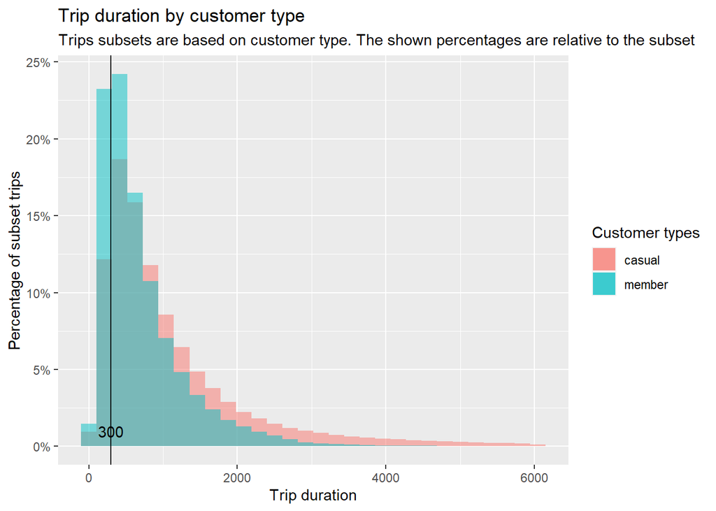

#### Usage throughout the day

Casuals use the service all along the day, with a cliff around 5:30 AM and a **peak around 5:30 PM**  
Member’s graph is similar casual’s graph with two variations:

- another **peak around 8:00 AM**
- less usage during working hours

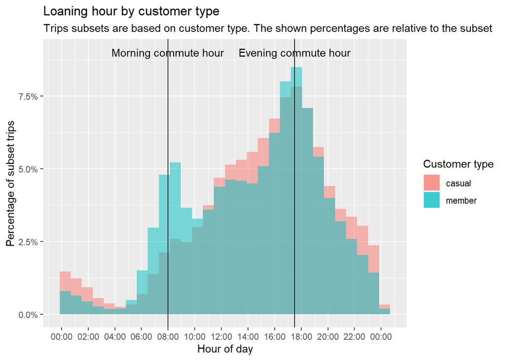

#### Usage throughout the week

*Casuals* use Cyclistic a lot more during the **weekend** than during the workweek. On the opposite, *members* have a close to **constant usage during the whole week** but they use the service slightly more during the workweek than during the weekend.

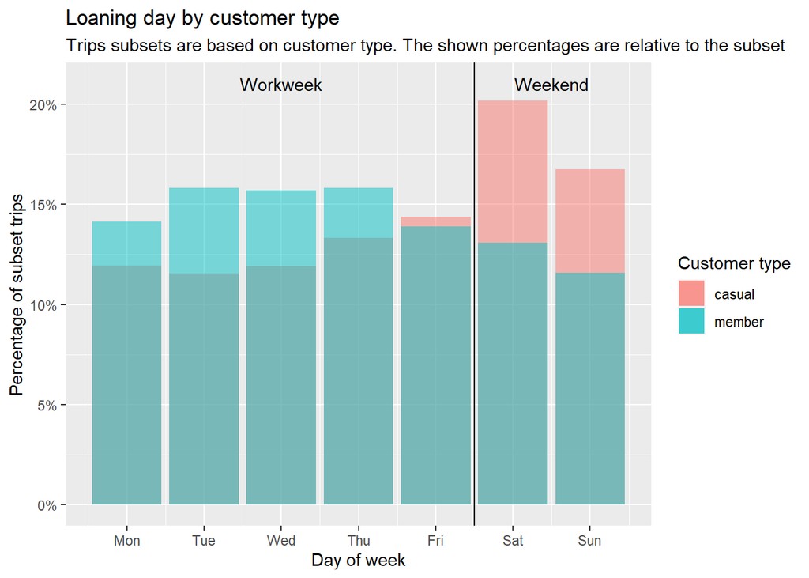

#### Usage throughout the year

*Casuals* enjoy Cyclistic during the **sunny months** (more than 15% usage during June to august) and avoid it during the cold ones (less than 2.5% usage during the December to February).  
*Members* follow the same trend, but their usage is much more **consistant**, with usage under 4% only in December and no month with usage above 12.5%.

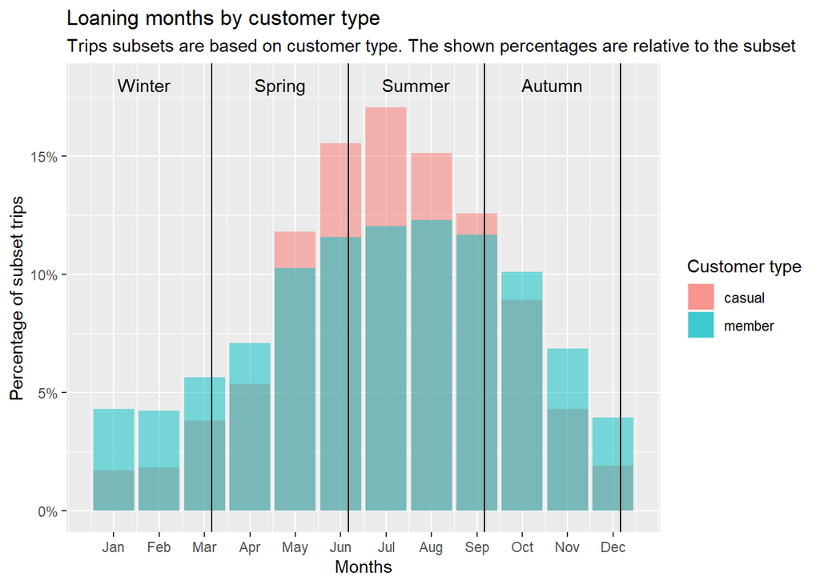

### Social usage

We consider that, if the user begin their trip in the **same minute and station** as another user, then he makes a ‘social usage’ of Cyclistic services.  
This measure is **far from exact** because two user that don’t know each others can take a bike in the same minute and station. Or two user that went on a bike trip could take more than a minute to lend the bike, or they could start in different stations and meet while on bike.  
However uncertain, the results are interesting. It shows that *casuals* use socially Cyclistic’s services **35%** of the time while *members* have a social usage only **20%** of the time.

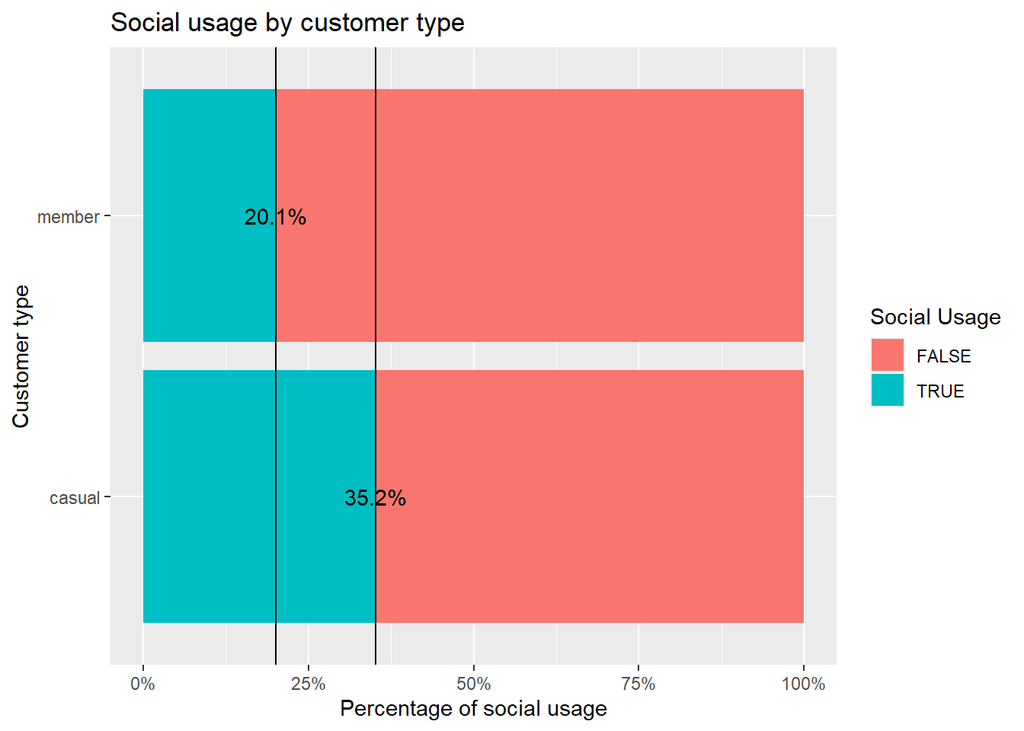

## Recommendations

The analysis aims at uncovering the differences between “casual” and “members” clients in order to understand what could **convince a “casual” client to become a “member” client**.  
To achieve this goal, we will make 3 recommendations that aims at producing *transitional offer* for casuals toward annual pass or *making the annual pass more interesting for casual*. Those recommendations are:

- Creation of a **summer pass** since it’s the season that interest casual the most. The member shall keep it’s current offer to have access to the service during the whole year.
- Creation of an **annual leisure pass** that gives:
  - full access during weekends
  - access between 19h-5h during workweek

    Those time ranges interest the casuals. The member shall keep his current offer to have access to the two commuting time range.
- On annual passes, allow the member to **loan a 2nd bike for free** ~3 times per week. This could make long time offers more attractive to casuals and at the same times it is a way for non customers to test the service in very favorable conditions (social usage).

## Appendix

### Unused findings

#### Usage by location

##### Location alone

At first glance, both members and casuals make a similar usage of Cyclistic in term of location alone: they are both centered on the **Lincoln park** area of ZIP code 60614. However, by analyzing the difference between member usage we can see that:

- *casuals* prefer **Streeterville** neighborhood, **Lincoln park** and **South Loop** a bit more
- *members* prefer **West Loop** and **Woodlawn** a bit more

These tendencies remain the same during the week, but get reinforced for Streeterville during the weekend.  
We only display the graphs based on the trip ending zone because the graph based on trip beginning zone are similar.

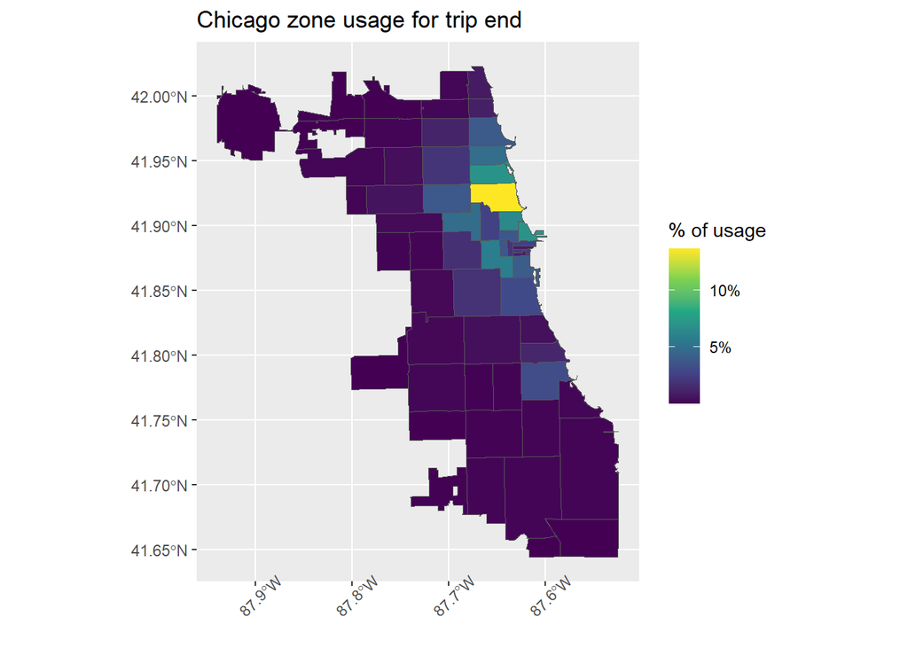

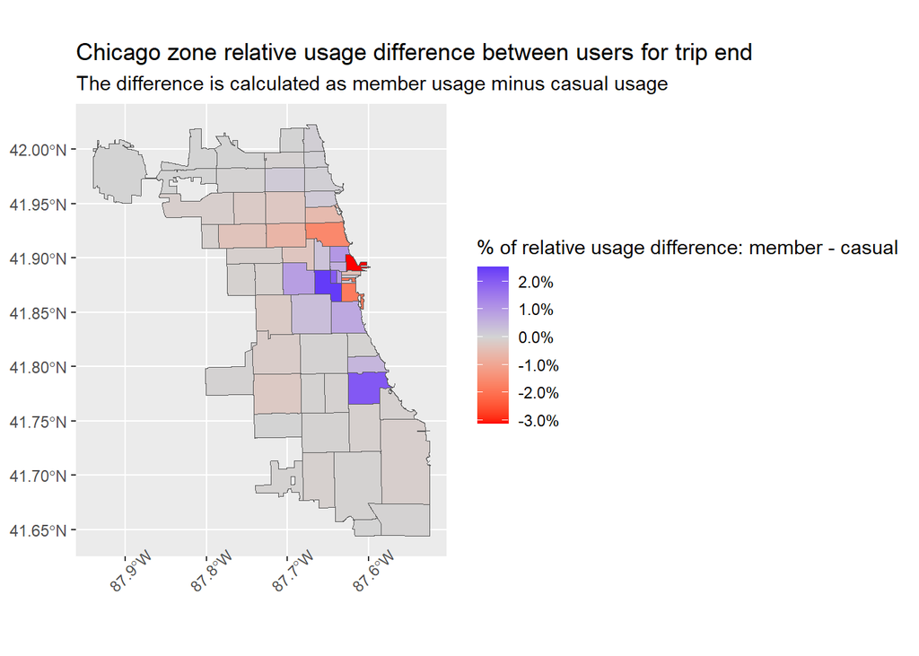

##### Location during workweek

Casuals are slightly more concentrated on Lincoln Park than members during the workweek

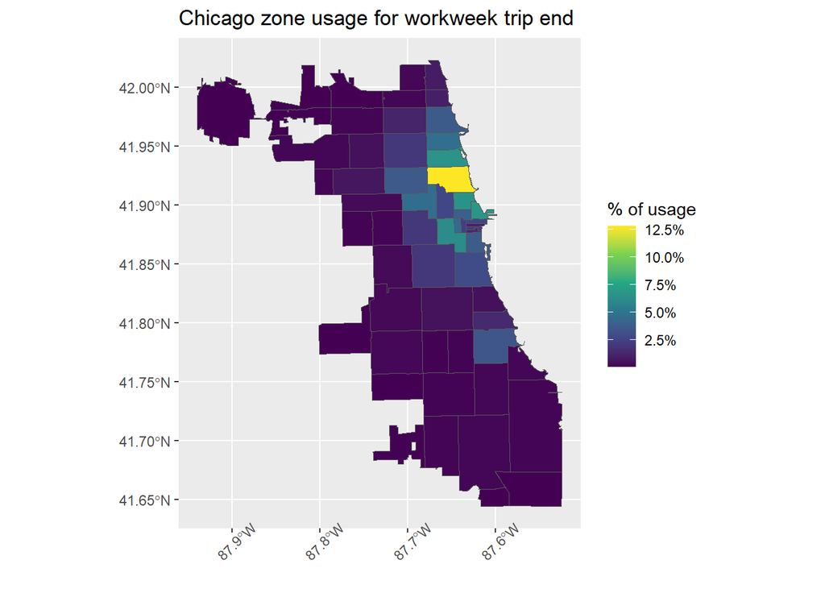

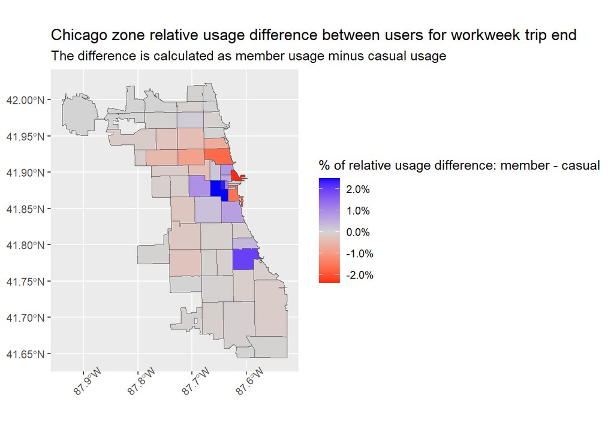

##### Location during weekend

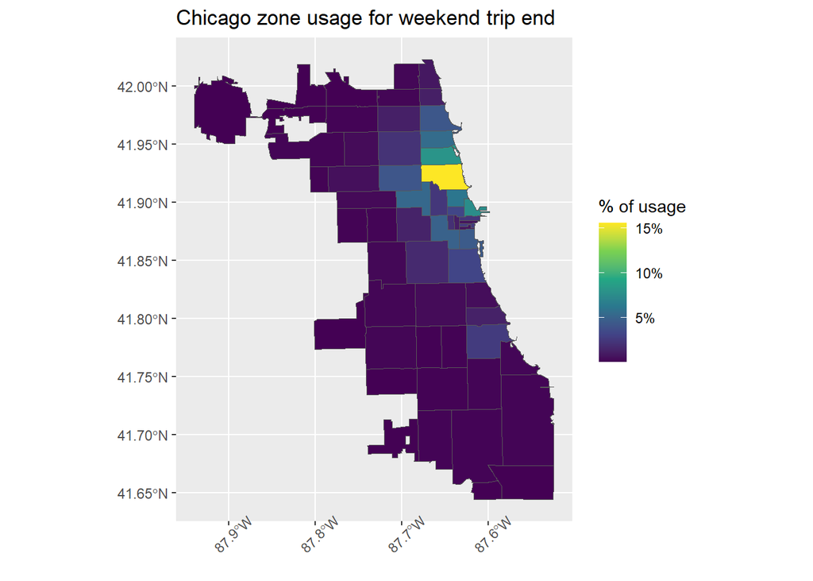

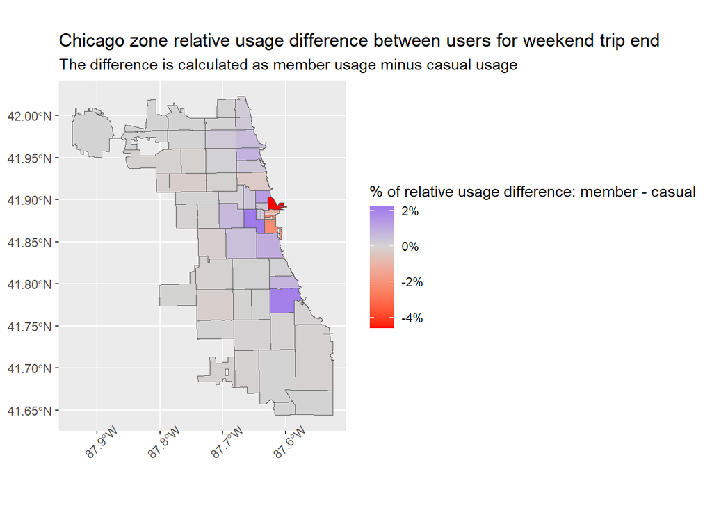

#### Unrelated findings

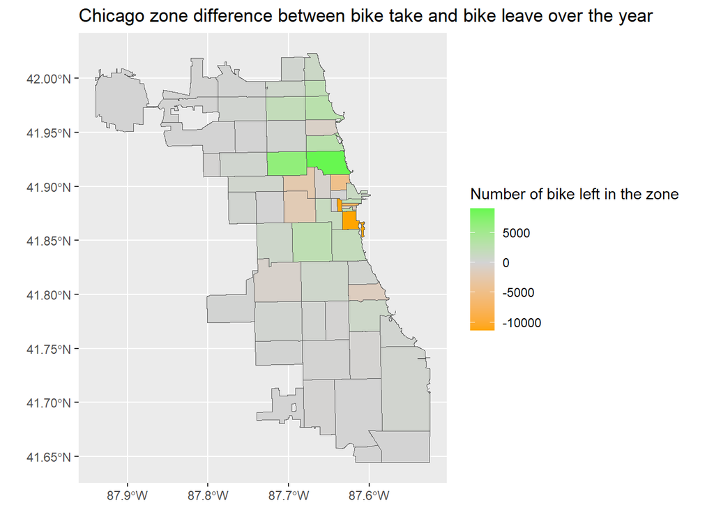